# WITS Model development

Olivier Restif

August 2014

# Background information

**Observed variables**

From each mouse: * **cfu** from whole liver and whole spleen (*except* at high concentrations when <10% is counted) and blood sample (20-30%). * **proportions** of the 8 WITS obtained by qPCR of a sample of ~$10^6$ DNA copies extracted from all colonies grown from whole organs and blood samples.

In addition, for each experiment: * one inoculum dose submitted to qPCR $\rightarrow$ **proportions** * three inoculum doses were plated $\rightarrow$ **cfu** * for M004 only, the 3 plates were then submitted to qPCR $\rightarrow$ **proportions** *after plate growth*

**Unobserved variables**

For each WITS in each mouse: * initial copy number from the inoculum * actual copy number in the blood, liver and spleen across time post-inoculation

**Parameters**

- Replication rates in liver and spleen (assumed to be zero in blood)
- Killing rates in liver and spleen (assumed to be zero in blood)
- Transfer rates from blood to liver and spleen (assumed to be always active)
- Transfer rates from liver and spleen to blood (assumed to be either time- or density-dependent)

$\Rightarrow$ Eight parameters per time point

**Statistical inference**

Assuming that the dynamics of all WITS are independent and identical, we have 8 WITS * 3 organs * 10 mice = 240 data items per time point.

Alternatively, it should be possible to estimate the parameters for each mouse at each time point, or even better, include mice as a kind of random effect. The best way to take this into account will depend on the statistical framework chosen.

**Note**: Because the data are expressed in terms of total CFU and proportions of WITS, and using the initial proportions of each WITS in the inoculum, another option would be to run 8 models in parallel for the 8 WITS and compare the results to individual mice.

**Modelling options**

Kolmogorov forward equations: system of ODE tracking the the probabilities $P\left(n_{B}(t),n_{L}(t),n_{S}(t)\right)$.

However, this would require N^3 equations, where N is the maximum number of copies of a single WITS in either location. In the naive mice, N can be as high as 10^5 , making it impractical.

A possible approach would be to only evaluate a small number of equations, involving variables whose values are currently above a threshold. Since copy numbers can only increase or decrease by one unit at a time, it should be possible to activate or deactivate ‘neighbouring’ equations at each iteration. $\rightarrow$ See Marc Baguelin’s ‘meta-dynamic adaptive system’ approach [(1)](http://www.sciencedirect.com/science/article/pii/S0167278905002149) [(2)](http://www.sciencedirect.com/science/article/pii/S0377042706003931).

Alternatively, use Gillespie stochastic simulations on individual WITS: with only 3 variables and 8 transitions, this is very quick. In addition, multiple simulations can be easily parallelised. However, inference becomes more complicated: approximate likelihood (reference needed) or ABC [(Toni et al. 2009)](http://rsif.royalsocietypublishing.org/content/6/31/187.abstract)

# Model description

The model tracks the number of copies of a single WITS in three locations simultaneously: blood ($n_B$), liver ($n_L$) and spleen ($n_S$). There are 8 transitions and 8 associated parameters:

| Transition | Rate | Effect |
| --- | --- | --- |
| 1. Transfer from B to L: | $c_L n_B$ | $n_B \leftarrow n_B - 1$ |
| . |  | $n_L \leftarrow n_L + 1$ |
| 2. Transfer from B to S: | $c_S n_B$ | $n_B \leftarrow n_B - 1$ |
| . |  | $n_S \leftarrow n_S + 1$ |
| 3. Replication in L: | $r_L n_L$ | $n_L \leftarrow n_L + 1$ |
| 4. Replication in S: | $r_S n_S$ | $n_S \leftarrow n_S + 1$ |
| 5. Killing in L: | $k_L n_L$ | $n_L \leftarrow n_L - 1$ |
| 6. Killing in S: | $k_S n_S$ | $n_S \leftarrow n_S - 1$ |
| 7. Transfer from L to B: | $e_L n_L$ | $n_B \leftarrow n_B + 1$ |
| . |  | $n_L \leftarrow n_L - 1$ |
| 8. Transfer from S to B: | $e_S n_L$ | $n_B \leftarrow n_B + 1$ |
| . |  | $n_S \leftarrow n_S - 1$ |

The following diagram represents the contributions of neighbour variables to changes in $P\left(n_{B},n_{L},n_{S}\right)$:

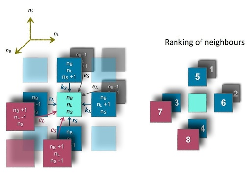

Model diagram

**Note:** Let ~ be the neighbour relation between 2 variables: by definition A~B iff B contributes to A. Properties: - if A~B then B~A - if A~B and A~C then B!~C

## Expected values

First, we derive the expressions for the marginal distributions in each organ. For example, in the blood: $P(n_B) = \sum_{n_L,n_S} P(n_B,n_L,n_S)$. Hence:

$\begin{aligned} \dot{P}(n_B) = &\sum_{n_L,n_S} \dot{P}(n_B,n_L,n_S) \\ \\ = & c_L \sum_{n_L,n_S} P(n_B+1,n_L-1,n_S) (n_B+1) + c_S \sum_{n_L,n_S} P(n_B+1,n_L,n_S-1) (n_B+1) \\ & + e_L \sum_{n_L,n_S} P(n_B-1,n_L+1,n_S) (n_L+1) + e_S \sum_{n_L,n_S} P(n_B-1,n_L,n_S+1) (n_S+1) \\ & + r_L \sum_{n_L,n_S} P(n_B,n_L-1,n_S) (n_L-1) + \sum_{n_L,n_S} r_S P(n_B,n_L,n_S-1) (n_S-1) \\ & + k_L \sum_{n_L,n_S} P(n_B,n_L+1,n_S) (n_L+1) + k_S \sum_{n_L,n_S} P(n_B,n_L,n_S+1) (n_S+1) \\ & - \sum_{n_L,n_S} \left[ (c_L+c_S) n_B + (e_L+r_L+k_L) n_L + (e_S+r_S+k_S) n_S \right] P(n_B,n_L,n_S) \\ \\ = & (c_L+c_S) (n_B+1) P(n_B+1) - (c_L+c_S) n_B P(n_B) \\ & + e_L \sum_{n_L} P(n_B-1,n_L+1) (n_L+1) + e_S \sum_{n_S} P(n_B-1,n_S+1) (n_S+1) \\ & + r_L \sum_{n_L} P(n_B,n_L-1) (n_L-1) + \sum_{n_S} r_S P(n_B,n_S-1) (n_S-1) \\ & + k_L \sum_{n_L} P(n_B,n_L+1) (n_L+1) + k_S \sum_{n_S} P(n_B,n_S+1) (n_S+1) \\ & - (e_L+r_L+k_L) \sum_{n_L} n_L P(n_B,n_L) - (e_S+r_S+k_S) \sum_{n_S} n_S P(n_B,n_S) \\ \\ = & (c_L+c_S) (n_B+1) P(n_B+1) - (c_L+c_S) n_B P(n_B) \\ & + e_L \sum_{n_L} n_L P(n_B-1,n_L) + e_S \sum_{n_S} n_S P(n_B-1,n_S) \\ & - e_L \sum_{n_L} n_L P(n_B,n_L) - e_S \sum_{n_S} n_S P(n_B,n_S) \end{aligned}$

$\begin{aligned} \dot{P}(n_B) = & (c_L+c_S) (n_B+1) P(n_B+1) + e_L \textbf{E}(N_L|n_B-1) P(n_B-1) + e_S \textbf{E}(N_S|n_B-1) P(n_B-1) \\ & -\left[ (c_L+c_S) n_B + e_L \textbf{E}(N_L|n_B) + e_S \textbf{E}(N_S|n_B) \right] P(n_B) \end{aligned}$

Likewise:

$\begin{aligned} \dot{P}(n_L) = & r_L (n_L-1) P(n_L-1) + (k_L+e_L) (n_L+1) P(n_L+1) + c_L \textbf{E}(N_B|n_L-1) P(n_L-1) \\ & - \left[ (r_L+k_L+e_L) n_L + c_L \textbf{E}(N_B|n_L) \right] P(n_L)\\ \\ \dot{P}(n_S) = & r_S (n_S-1) P(n_S-1) + (k_S+e_S) (n_S+1) P(n_S+1) + c_S \textbf{E}(N_B|n_S-1) P(n_S-1) \\ & - \left[ (r_S+k_S+e_S) n_S + c_S \textbf{E}(N_B|n_S) \right] P(n_S) \end{aligned}$

Hence the dynamics of the expectation:

$\begin{aligned} \dot{\textbf{E}}(N_B) = &\sum_{n_B} n_B \dot{P}(n_B) \\ = & \sum_{n_B} n_B (c_L+c_S) (n_B+1) P(n_B+1) - \sum_{n_B} n_B (c_L+c_S) n_B P(n_B) \\ & + \sum_{n_B} n_B e_L P(n_B-1) \textbf{E}(N_L|n_B-1) - \sum_{n_B} n_B e_L P(n_B) \textbf{E}(N_L|n_B) \\ & + \sum_{n_B} n_B e_S P(n_B-1) \textbf{E}(N_S|n_B-1) - \sum_{n_B} n_B e_S P(n_B) \textbf{E}(N_S|n_B) \\ \\ = & - \sum_{n_B} (c_L+c_S) n_B P(n_B) + \sum_{n_B} e_L P(n_B) \textbf{E}(N_L|n_B) + \sum_{n_B} e_S P(n_B) \textbf{E}(N_S|n_B) \\ \\ \dot{\textbf{E}}(N_B) = & - (c_L+c_S) \textbf{E}(N_B) + e_L \textbf{E}(N_L) + e_S \textbf{E}(N_S)\\ \end{aligned}$

Likewise we can get:

$\begin{aligned} \dot{\textbf{E}}(N_L) = & c_L \textbf{E}(N_B) + (r_L-k_L-e_L) \textbf{E}(N_L)\\ \dot{\textbf{E}}(N_S) = & c_S \textbf{E}(N_B) + (r_S-k_S-e_S) \textbf{E}(N_S)\\ \end{aligned}$

In matrix form: $\dot{\textbf{N}} = \textbf{A} * \textbf{N}$, with

$\textbf{N} = \begin{pmatrix} \textbf{E} N_B \\ \textbf{E} N_L \\ \textbf{E} N_S \end{pmatrix}, \textbf{A} = \begin{pmatrix} -(c_L+c_S) & e_L & e_S \\ cL & r_L-k_L-e_L & 0 \\ cS & 0 & r_S-k_S-e_S \end{pmatrix}$

which can be solved as $\textbf{N}(t) = \exp (t \mathbf{A}) * \textbf{N}(0)$. Although this does not have a closed analytical form (see Mathematica notebook), it can be solved numerically very easily.

## Covariance:

$\begin{aligned} \dot{\textbf{E}}(N_B^2) = &\sum_{n_B} n_B^2 \dot{P}(n_B) \\ = & (c_L+c_S) \sum_{n_B} n_B^2 (n_B+1) P(n_B+1) - (c_L+c_S) \sum_{n_B} n_B^3 P(n_B) \\ & + e_L \sum_{n_B} n_B^2 P(n_B-1) \textbf{E}(N_L|n_B-1) - e_L \sum_{n_B} n_B^2 P(n_B) \textbf{E}(N_L|n_B) \\ & + e_S \sum_{n_B} n_B^2 P(n_B-1) \textbf{E}(N_S|n_B-1) - n_B^2 \sum_{n_B} e_S P(n_B) \textbf{E}(N_S|n_B) \\ \\ = & - (c_L+c_S) \sum_{n_B} (2 n_B+1) (n_B+1) P(n_B+1) + e_L \sum_{n_B} (2 n_B-1) P(n_B-1) \textbf{E}(N_L|n_B-1) + e_S \sum_{n_B} (2 n_B-1) P(n_B-1) \textbf{E}(N_S|n_B-1)\\ = & - (c_L+c_S) \sum_{n_B} (2 n_B-1) (n_B) P(n_B) + e_L \sum_{n_B} (2 n_B+1) P(n_B) \textbf{E}(N_L|n_B) + e_S \sum_{n_B} (2 n_B+1) P(n_B) \textbf{E}(N_S|n_B)\\ \\ \dot{\textbf{E}}(N_B^2) = & (c_L+c_S) \textbf{E}(N_B) + e_L \textbf{E}(N_L) + e_S \textbf{E}(N_S) - 2 (c_L+c_S) \textbf{E}(N_B^2) + 2 e_L \textbf{E}(N_B N_L) + 2 e_S \textbf{E}(N_B N_S)\\ \\ \end{aligned}$

This leads to the following equation for the variance $\textbf{V}(N_B) = \textbf{E}(N_B^2)-\textbf{E}(N_B)^2$:

$\begin{aligned} \dot{\textbf{V}}(N_B) = &\dot{\textbf{E}}(N_B^2) - 2 \textbf{E}(N_B) \dot{\textbf{E}}(N_B)\\ = &(c_L+c_S) \textbf{E}(N_B) + e_L \textbf{E}(N_L) + e_S \textbf{E}(N_S) - 2 (c_L+c_S) \textbf{E}(N_B^2) + 2 e_L \textbf{E}(N_B N_L) + 2 e_S \textbf{E}(N_B N_S)\\ &- 2 \textbf{E}(N_B) \left[ - (c_L+c_S) \textbf{E}(N_B) + e_L \textbf{E}(N_L) + e_S \textbf{E}(N_S) \right]\\ \\ \dot{\textbf{V}}(N_B) = &(c_L+c_S) \textbf{E}(N_B) + e_L \textbf{E}(N_L) + e_S \textbf{E}(N_S) - 2 (c_L+c_S) \textbf{V}(N_B) + 2 e_L \textbf{V}(N_B,N_L) + 2 e_S \textbf{V}(N_B,N_S) \end{aligned}$

Next, variance of $N_L$ and $N_S$:

$\begin{aligned} \dot{\textbf{E}}(N_L^2) = &\sum_{n_L} n_L^2 \dot{P}(n_L) \\ = & r_L \sum_{n_L} n_L^2 (n_L-1) P(n_L-1) - r_L \sum_{n_L} n_L^2 n_L P(n_L) \\ & + (k_L+e_L) \sum_{n_L} n_L^2 (n_L+1) P(n_L+1) - (k_L+e_L) \sum_{n_L} n_L^2 n_L P(n_L) \\ & + c_L \sum_{n_L} n_L^2 \textbf{E}(N_B|n_L-1) P(n_L-1) - c_L \sum_{n_L} n_L^2 \textbf{E}(N_B|n_L) P(n_L)\\ \\ = & r_L \sum_{n_L} (2n_L-1) (n_L-1) P(n_L-1) - (k_L+e_L) \sum_{n_L} (2n_L+1) (n_L+1) P(n_L+1) + c_L \sum_{n_L} (2n_L-1) \textbf{E}(N_B|n_L-1) P(n_L-1) \\ = & r_L \sum_{n_L} (2n_L+1) n_L P(n_L) - (k_L+e_L) \sum_{n_L} (2n_L-1) n_L P(n_L) + c_L \sum_{n_L} (2n_L+1) \textbf{E}(N_B|n_L) P(n_L) \\ \\ \dot{\textbf{E}}(N_L^2) = & (r_L+k_L+e_L) \textbf{E}(N_L) + c_L \textbf{E}(N_B) + 2 (r_L-k_L-e_L) \textbf{E}(N_L^2) + 2 c_L \textbf{E}(N_B N_L)\\ \\ \dot{\textbf{E}}(N_S^2) = & (r_S+k_S+e_S) \textbf{E}(N_S) + c_S \textbf{E}(N_B) + 2 (r_S-k_S-e_S) \textbf{E}(N_S^2) + 2 c_S \textbf{E}(N_B N_S)\\ \end{aligned}$

$\begin{aligned} \dot{\textbf{V}}(N_L) = &\dot{\textbf{E}}(N_L^2) - 2 \textbf{E}(N_L) \dot{\textbf{E}}(N_L)\\ = & (r_L+k_L+e_L) \textbf{E}(N_L) + c_L \textbf{E}(N_B) + 2 (r_L-k_L-e_L) \textbf{E}(N_L^2) + 2 c_L \textbf{E}(N_B N_L)\\ &- 2 \textbf{E}(N_L) \left[c_L \textbf{E}(N_B) + (r_L-k_L-e_L) \textbf{E}(N_L) \right]\\ \\ \dot{\textbf{V}}(N_L) = & c_L \textbf{E}(N_B) + (r_L+k_L+e_L) \textbf{E}(N_L) + 2 (r_L-k_L-e_L) \textbf{V}(N_L) + 2 c_L \textbf{V}(N_B,N_L)\\ \\ \dot{\textbf{V}}(N_S) = & c_S \textbf{E}(N_B) + (r_S+k_S+e_S) \textbf{E}(N_S) + 2 (r_S-k_S-e_S) \textbf{V}(N_S) + 2 c_S \textbf{V}(N_B,N_S) \end{aligned}$

The covariances can be calculated form the marginal distributions $P(n_B,n_L)$ and $P(n_B,n_S)$.

$\begin{aligned} \dot{P}(n_B,n_L) = & c_L(n_B+1) P(n_B+1,n_L-1) + e_L (n_L+1) P(n_B-1,n_L+1) + c_S (n_B+1) P(n_B+1,n_L) + e_S \textbf{E}(N_S|n_B-1,n_L) P(n_B-1,n_L)\\ & + r_L (n_L-1) P(n_B,n_L-1) + k_L (n_L+1) P(n_B,n_L+1) \\ & - \left[ (c_L+c_S) n_B + (e_L+r_L+k_L) n_L + e_S \textbf{E}(N_S|n_B,n_L)\right] P(n_B,n_L)\\ \end{aligned}$

Hence:

$\begin{aligned} \dot{\textbf{E}}(N_B N_L) = &\sum_{n_B,n_L} n_B n_L \dot{P}(n_B,n_L) \\ = & c_L \sum_{n_B,n_L} n_B n_L (n_B+1) P(n_B+1,n_L-1) + e_L \sum_{n_B,n_L} n_B n_L (n_L+1) P(n_B-1,n_L+1) \\ & + c_S \sum_{n_B,n_L} n_B n_L (n_B+1) P(n_B+1,n_L) + e_S \sum_{n_B,n_L} n_B n_L \textbf{E}(N_S|n_B-1,n_L) P(n_B-1,n_L)\\ & + r_L \sum_{n_B,n_L} n_B n_L (n_L-1) P(n_B,n_L-1) + k_L \sum_{n_B,n_L} n_B n_L (n_L+1) P(n_B,n_L+1) \\ & - \sum_{n_B,n_L} n_B n_L \left[ (c_L+c_S) n_B + (e_L+r_L+k_L) n_L + e_S \textbf{E}(N_S|n_B,n_L)\right] P(n_B,n_L)\\ \\ = & c_L \sum_{n_B} n_B (n_B+1) P(n_B+1) \left[1+\textbf{E}(N_L|n_B+1)\right] + e_L \sum_{n_L} n_L (n_L+1) P(n_L+1) \left[1+\textbf{E}(N_B|n_L+1)\right]\\ & + c_S \sum_{n_B} n_B (n_B+1) P(n_B+1) \textbf{E}(N_L|n_B+1) + e_S \sum_{n_B} n_B P(n_B-1) \left[ \sum_{n_L,n_S} n_L n_S P(n_S|n_B-1,n_L) P(n_L|n_B-1) \right]\\ & + r_L \sum_{n_L} n_L (n_L-1) \textbf{E}(N_B|nL-1) P(n_L-1) + k_L \sum_{n_L} n_L (n_L+1) \textbf{E}(N_B|n_L+1) P(n_L+1) \\ & - (c_L+c_S) \textbf{E}(N_B^2 N_L) - (e_L+r_L+k_L) \textbf{E}(N_B N_L^2) - e_S \sum_{n_B} n_B P(n_B) \left[ \sum_{n_L,n_S} n_L n_S P(n_S,n_L|n_B)\right]\\ \\ = & c_L \textbf{E}(N_B^2) - c_L \textbf{E}(N_B) + c_L \textbf{E}(N_B^2 N_L) - c_L \textbf{E}(N_B N_L) + e_L \textbf{E}(N_L^2) - e_L \textbf{E}(N_L) + e_L \textbf{E}(N_B N_L^2) - e_L \textbf{E}(N_B N_L)\\ & + c_S \textbf{E}(N_B^2 N_L) - c_S \textbf{E}(N_B N_L) + e_S \textbf{E}(N_B N_L N_S) + e_S \textbf{E}(N_L N_S) \\ & + r_L \textbf{E}(N_B N_L^2) + r_L \textbf{E}(N_B N_L) + k_L \textbf{E}(N_B N_L^2) - k_L \textbf{E}(N_B N_L) \\ & - c_L \textbf{E}(N_B^2 N_L) - c_S \textbf{E}(N_B^2 N_L) - (e_L+r_L+k_L) \textbf{E}(N_B N_L^2) - e_S \textbf{E}(N_B N_L N_S)\\ \\ = & c_L \textbf{E}(N_B^2) - c_L \textbf{E}(N_B) - c_L \textbf{E}(N_B N_L) + e_L \textbf{E}(N_L^2) - e_L \textbf{E}(N_L) - e_L \textbf{E}(N_B N_L) - c_S \textbf{E}(N_B N_L) + e_S \textbf{E}(N_L N_S) + r_L \textbf{E}(N_B N_L) - k_L \textbf{E}(N_B N_L) \\ \\ \dot{\textbf{E}}(N_B N_L) = &- c_L \textbf{E}(N_B) - e_L \textbf{E}(N_L) + c_L \textbf{E}(N_B^2) + e_L \textbf{E}(N_L^2) + (-c_L-c_S-e_L+r_L-k_L) \textbf{E}(N_B N_L) + e_S \textbf{E}(N_L N_S)\\ \\ \end{aligned}$

$\begin{aligned} \dot{\textbf{V}}(N_B,N_L) = & \dot{\textbf{E}}(N_B N_L) - \textbf{E}(N_B) \dot{\textbf{E}}(N_L) - \textbf{E}(N_L) \dot{\textbf{E}}(N_B)\\ = & - c_L \textbf{E}(N_B) - e_L \textbf{E}(N_L) + c_L \textbf{E}(N_B^2) + e_L \textbf{E}(N_L^2) + (-c_L-c_S-e_L+r_L-k_L) \textbf{E}(N_B N_L) + e_S \textbf{E}(N_L N_S) \\ & - \textbf{E}(N_B) \left[c_L \textbf{E}(N_B) + (r_L-k_L-e_L) \textbf{E}(N_L) \right] \\ & - \textbf{E}(N_L) \left[- (c_L+c_S) \textbf{E}(N_B) + e_L \textbf{E}(N_L) + e_S \textbf{E}(N_S) \right]\\ \\ \dot{\textbf{V}}(N_B,N_L) = &- c_L \textbf{E}(N_B) - e_L \textbf{E}(N_L) + c_L \textbf{V}(N_B) + e_L \textbf{V}(N_L) + (-c_L-c_S-e_L+r_L-k_L) \textbf{V}(N_B,N_L) + e_S \textbf{V}(N_L,N_S) \end{aligned}\\$

Likewise:

$\begin{aligned} \dot{\textbf{E}}(N_B N_S) = & - c_S \textbf{E}(N_B) - e_S \textbf{E}(N_S) + c_S \textbf{E}(N_B^2) + e_S \textbf{E}(N_S^2) + (-c_L-c_S-e_S+r_S-k_S) \textbf{E}(N_B N_S) + e_L \textbf{E}(N_L N_S)\\ \\ \dot{\textbf{V}}(N_B,N_S) = & - c_S \textbf{E}(N_B) - e_S \textbf{E}(N_S) + c_S \textbf{V}(N_B) + e_S \textbf{V}(N_S) + (-c_L-c_S-e_S+r_S-k_S) \textbf{V}(N_B,N_S) + e_L \textbf{V}(N_L,N_S)\\ \end{aligned}$

Next:

$\begin{aligned} \dot{P}(n_L,n_S) = & c_L \textbf{E}(N_B|n_L-1,n_S) P(n_L-1,n_S) + c_S \textbf{E}(N_B|n_L,n_S-1) P(n_L,n_S-1) \\ & + e_L (n_L+1) P(n_L+1,n_S) + e_S (nS+1) P(n_L,n_S+1)\\ & + k_L (n_L+1) P(n_L+1,n_S) + k_S (n_S+1) P(n_L,n_S+1)\\ & + r_L (n_L-1) P(n_L-1,n_S) + r_S (n_S-1) P(n_L,n_S-1) \\ & - \left[ (c_L+c_S) \textbf{E}(N_B|n_L,n_S) + (e_L+k_L+r_L) n_L + (e_S+k_S+r_S) n_S\right] P(n_L,n_S)\\ \end{aligned}$

Hence:

$\begin{aligned} \dot{\textbf{E}}(N_L N_S) = & \sum_{n_L,n_S} n_L n_S \dot{P}(n_L,n_S)\\ = & c_L \sum_{n_L,n_S} (n_L+1) n_S \textbf{E}(N_B|n_L,n_S) P(n_L,n_S) + c_S \sum_{n_L,n_S} n_L (n_S+1) \textbf{E}(N_B|n_L,n_S) P(n_L,n_S) \\ & + e_L \sum_{n_L,n_S} (n_L-1) n_S n_L P(n_L,n_S) + e_S \sum_{n_L,n_S} n_L n_S (nS-1) P(n_L,n_S)\\ & + k_L \sum_{n_L,n_S} n_L n_S (n_L-1) P(n_L,n_S) + k_S \sum_{n_L,n_S} n_L n_S (n_S-1) P(n_L,n_S)\\ & + r_L \sum_{n_L,n_S} n_L n_S (n_L+1) P(n_L,n_S) + r_S \sum_{n_L,n_S} n_L n_S (n_S+1) P(n_L,n_S) \\ & - (c_L+c_S) \sum_{n_L,n_S} n_L n_S \textbf{E}(N_B|n_L,n_S) P(n_L,n_S) - (e_L+k_L+r_L) \textbf{E}(N_L^2 N_S) - (e_S+k_S+r_S) \textbf{E}(N_L N_S^2)\\ \\ = & (c_L+c_S) \textbf{E}(N_B N_L N_S) + c_L \textbf{E}(N_B N_S) + c_S \textbf{E}(N_B N_L)\\ & + (e_L+k_L+r_L) \textbf{E}(N_L^2 N_S) + (e_S+k_S+r_S) \textbf{E}(N_L N_S^2) - (e_L+e_S+k_L+k_S-r_L-r_S) \textbf{E}(N_L N_S)\\ & - (c_L+c_S) \textbf{E}(N_B n_L n_S) - (e_L+k_L+r_L) \textbf{E}(N_L^2 N_S) - (e_S+k_S+r_S) \textbf{E}(N_L N_S^2)\\ \\ \dot{\textbf{E}}(N_L N_S) = & c_L \textbf{E}(N_B N_S) + c_S \textbf{E}(N_B N_L) + (-e_L-e_S-k_L-k_S+r_L+r_S) \textbf{E}(N_L N_S) \end{aligned}$

Finally:

$\begin{aligned} \dot{\textbf{V}}(N_L,N_S) = & \dot{\textbf{E}}(N_L N_S) - \textbf{E}(N_S) \dot{\textbf{E}}(N_L) - \textbf{E}(N_L) \dot{\textbf{E}}(N_L)\\ = & c_L \textbf{E}(N_B N_S) + c_S \textbf{E}(N_B N_L) + (-e_L-e_S-k_L-k_S+r_L+r_S) \textbf{E}(N_L N_S)\\ & - \textbf{E}(N_S) \left[ c_L \textbf{E}(N_B) + (r_L-k_L-e_L) \textbf{E}(N_L)\right]\\ & - \textbf{E}(N_L) \left[ c_S \textbf{E}(N_B) + (r_S-k_S-e_S) \textbf{E}(N_S)\right]\\ \\ \dot{\textbf{V}}(N_L,N_S) = & c_L \textbf{V}(N_B,N_S) + c_S \textbf{V}(N_B,N_L) + (-e_L-e_S-k_L-k_S+r_L+r_S) \textbf{V}(N_L,N_S) \end{aligned}$

### Matrix form

Let $\textbf{M} = {}^{T}\left[\textbf{V}(N_B), \textbf{V}(N_L), \textbf{V}(N_S), \textbf{V}(N_B,N_L), \textbf{V}(N_B,N_S), \textbf{V}(N_L,N_S) \right]$. Then: $\dot{\textbf{M}}(t) = \textbf{B} * \textbf{N}(t) + \textbf{C} * \textbf{M}(t)$

$\textbf{B} = \begin{pmatrix} c_L+c_S & e_L & e_S \\ c_L & r_L+k_L+e_L & 0 \\ c_S & 0 & r_S+k_S+e_S \\ -c_L & -e_L & 0 \\ -c_S & 0 & -e_S \\ 0 & 0 & 0 \end{pmatrix}$

$\textbf{C} = \begin{pmatrix} -2c_L-2c_S & 0 & 0 & 2e_L & 2e_S & 0 \\ 0 & 2r_L-2k_L-2e_L & 0 & 2c_L & 0 & 0 \\ 0 & 0 & 2r_S-2k_S-2e_S & 0 & 2c_S & 0 \\ c_L & e_L & 0 & -c_L-c_S-e_L+r_L-k_L & 0 & e_S \\ c_S & 0 & e_S & 0 & -c_L-c_S-e_S+r_S-k_S & e_L \\ 0 & 0 & 0 & c_L & c_S & -e_L-e_S-k_L-k_S+r_L+r_S \end{pmatrix}$

We can solve the equation: $\dot{\textbf{M}}(t) - \textbf{C} * \textbf{M}(t) = \textbf{B} * \exp(t\ \textbf{A}) * \textbf{N}(0)$ using Duhamel’s formula.

The general solution is $\textbf{M}(t) = \exp(t\ \textbf{C}) * \textbf{M}(0) + \exp(t\textbf{C}) * \left[ \int_{0}^{t} \exp(-s \textbf{C}) * B * \exp(s \textbf{A}) ds \right] * \textbf{N}(0)$.

It remains to be tested how fast the integral can be calculated. In principle it could be parallelised: the function to integrate is a 6x3 matrix.

## Probability Generating Functions

PGF of $N_B$:

$\begin{aligned} \dot{\textbf{E}}(z^{N_B}) = & \sum_{n_B} z^{n_B} \dot{P}(n_B) \\ = & (c_L+c_S) \sum_{n_B} z^{n_B} (n_B+1) P(n_B+1) - (c_L+c_S) z \sum_{n_B} z^{n_B-1} n_B P(n_B) \\ & + e_L z \sum_{n_B} z^{n_B-1} \textbf{E}(N_L|n_B-1) P(n_B-1) - e_L \sum_{n_B} z^{n_B} \textbf{E}(N_L|n_B) P(n_B) \\ & + e_S z \sum_{n_B} z^{n_B-1} \textbf{E}(N_S|n_B-1) P(n_B-1) - e_S \sum_{n_B} z^{n_B} \textbf{E}(N_S|n_B) P(n_B) \\ \\ \frac{\partial \textbf{E}(z^{N_B})}{\partial t}= & (c_L+c_S) (1-z) \frac{\partial \textbf{E}(z^{N_B})}{\partial z} - e_L (1-z) \textbf{E}(N_L z^{N_B}) - e_S (1-z) \textbf{E}(N_S z^{N_B}) \end{aligned}$

The bivariate expectations can be calculated based on $P(n_B,n_L)$, using:

$\begin{aligned} \dot{P}(n_B,n_L) = & c_L (n_B+1) P(n_B+1,n_L-1) + c_S (n_B+1) P(n_B+1,n_L) + e_L (n_L+1) P(n_B-1,n_L+1) + e_S \textbf{E}(N_S|n_B-1,n_L) P(n_B-1,n_L)\\ & - \left[ (c_L+c_S) n_B + e_L n_L + e_S \textbf{E}(N_S|n_B,n_L) \right] P(n_B,n_L) \\ \end{aligned}$

$\begin{aligned} \dot{\textbf{E}}(N_L z^{N_B}) = & \sum_{n_B,n_L} n_L z^{n_B} \dot{P}(n_B,n_L) \\ = & c_L \sum_{n_B,n_L} n_L (n_B+1) z^{n_B} P(n_B+1,n_L-1) - c_L \sum_{n_B,n_L} n_L n_B z^{n_B} P(n_B,n_L) \\ & + c_S \sum_{n_B,n_L} n_L (n_B+1) z^{n_B} P(n_B+1,n_L) - c_S \sum_{n_B,n_L} n_L n_B z^{n_B} P(n_B,n_L) \\ & + e_L \sum_{n_B,n_L} n_L (n_L+1) z^{n_B} P(n_B-1,n_L+1) - e_L \sum_{n_B,n_L} n_L^2 z^{n_B} P(n_B,n_L) \\ & + e_S \sum_{n_B,n_L} n_L z^{n_B} \textbf{E}(N_S|n_B-1,n_L) P(n_B-1,n_L) - e_S \sum_{n_B,n_L} n_L z^{n_B} \textbf{E}(N_S|n_B,n_L) P(n_B,n_L) \\ \\ = & (c_L+c_S) (1-z) \frac{\partial \textbf{E}(N_L z^{N_B})}{\partial z} + c_L \frac{\partial \textbf{E}(z^{N_B})}{\partial z} -e_L (1-z) \textbf{E}(N_L^2 z^{N_B}) - e_L z \textbf{E}(N_L z^{N_B}) - e_S (1-z) \textbf{E}(N_L N_S z^{N_B})\\ \end{aligned}$

=> No closed form when $e_L > 0$.

The same problem will occur with $c_L$ when calculating $\textbf{E}(N_B z^{N_L})$ for the PGF of $N_L$.

# Metadynamical algorithm to numerically solve the master equations

Given a threshold $\epsilon \ll 1$, at the current time *t* : 1. any variable $P\left(n_{B},n_{L},n_{S}\right) > \epsilon$ is deemed *active* 2. any variable (unless active itself) neighbouring an active variable is deemed *passive* 3. all other variables are deemed *inactive* and their value set to 0 4. calculate the derivatives of active and passive variables (Runge-Kutta) and update their values 5. any active variable whose value is now < $\epsilon$ is set to inactive 6. any passive variable whose value is now > $\epsilon$ is set to active 7. update the list of passive variables using the new list of active variables 8. go back to 4

## Implementation

**Matrix of active and passive variables: var.mat**

Column names: nB, nL, nS, Value, Neighbour.1,…, Neighbour.8

- nB, nL, nS: integers
- Value: P(nB, nL, nS)
- Neighbour.x: row number of neighbour *x*

**Note**: the 8 neighbours must always be in the same order:

1. nB-1,nL,nS+1
2. nB-1,nL+1,nS
3. nB,nL-1,nS
4. nB,nL,nS-1
5. nB,nL,nS+1
6. nB,nL+1,nS
7. nB+1,nL-1,nS
8. nB+1,nL,nS-1

=> This information can be stored in an 8x3 matrix with rows: c(-1,0,1), c(-1,1,0), c(0,-1,0) etc.

As a result, if variable j is Neighbour.(k) of variable i, then i is Neighbour.(9-k) of j.

**Required information:** * Parameter values * Period of time considered * Initial conditions * Function calculating dP/dt given parameter values and var.mat matrix

**Initialisation**

1. Fill in the matrix (except the Neighbour.x columns) with active variables as given in the initial conditions, by increasing values of nB, then nL then nS.
2. Add passive variables: for each active variable i and for each potential neighbour x: if is.na(var.mat[i,Neighbour.x]), calculate the coordinates (nB,nL,nS) of the neighbour and:
   - if there is already an entry at row j in var.mat, set var.mat[i,Neighbour.x] <- j and var.mat[j,Neighbour.(9-x)] <- i;
   - else, create a new row k, set Active<-0, Value<-0 and Neighbour.(9-x)<-i, and set var.mat[i,Neighbour.x] <- k, then connect to existing passive variables as relevant.

## Current best working version: Metadynamics 1i + Likelihood 3j

- With R the fastest version of diff() is map.sum(), which uses rowSums() and cbind(). The parallelised version is much slower.
- Two sources of error:
  - The RK4 step cannot use the inactive neighbours of passive variables => Must use small values of h
  - Values below eps are chopped at every time step
- **Version 1c** (04/09/2012): Matrix handling: An incremental metadynamical algorithm, only adding neighbours of newly active cells (and connecting existing passive cells), is currently the best option (much faster than version 1b which rebuilds the matrix at each time step), even though it is not fast enough yet.
- **Version 1e** (05/09/2012) keeps matrix handling in R as with 1c, but calls a C function to calculate the RK4 step.
- **Version 1f** (11/09/2012): uses .Call to run the whole RK4 simulation in C. Substantial time gain.
- **Version 1g** (23/11/2012): BUG CORRECTION: use Calloc instead of alloc/realloc; maximum value of n must be specified.
- **Version 1h** (04/12/2012): MODEL CORRECTION (for likelihood only): model the observation error term $f(\omega|\nu,n)$ with a gamma distribution instead of normal, and set $f(\omega|0) = \delta_0$.
  - BUG CORRECTION: r_phi[0] … r_phi[2]
- **Version 1i/2i** (30/01/2013): LIKELIHOOD CORRECTIONS: revised decomposition of the likelihood (see below); observation error using a normal distribution (except if $\omega$=0)
- **Version 3j** (25/03/2013): LIKELIHOOD CORRECTIONS: based on independent qPCR series, use a log-normal distribution for the observation process, and calculate the likelihood for multiple mice from one model calculation at one time point. Note that the likelihood computation is not parallelized across mice.

**Tests**

Version 1c:

```r
> my.init <- matrix(c(10,0,0,1),1,byrow=T)
> my.par <- list(cL=1,cS=1,eL=0,eS=0,rL=2,rS=2,kL=2,kS=2)
> system.time(my.test <- meta.RK4c(my.par,my.init,c(0,0.5),eps=1e-6,h=1e-4))
   user  system elapsed
 19.642   1.412  21.051
> c(my.test$RK.time,my.test$mat.time)
[1] 17.229598  2.459982
> nrow(my.test$var.mat)
[1] 1994
> my.test.mat <- my.test$var.mat
> av.nB <- sum(my.test.mat[,1]*my.test.mat[,4])
> av.nB/(10*exp(-2*0.5))-1 # Check average nB follows an exponential decay
[1] -0.000779868
> av.nL <- sum(my.test.mat[,2]*my.test.mat[,4])
> av.nS <- sum(my.test.mat[,3]*my.test.mat[,4])
> 10-av.nB-(av.nL)-(av.nS) # Loss of bacteria due to killing
[1] 0.01685433
```

Comparison between versions 1b and 1c:

```r
> my.init <- matrix(c(
+   10,9,10,0.25,
+   10,10,10,0.5,
+   10,11,10,0.25),
+           3,byrow=T)
> my.par <- list(cL=1,cS=1,eL=0,eS=0,rL=1,rS=1,kL=1,kS=1)

> system.time(my.test <- meta.RK4c(my.par,my.init,c(0,0.1),eps=1e-6,h=1e-4))
   user  system elapsed
  5.010   0.529   5.536
> 1-sum(my.test$var.mat[,4])
[1] 0.0001528206
> nrow(my.test$var.mat)
[1] 1874
> #(sum(my.test$var.mat[1,4])/exp(-10*2*1))-1
> c(my.test$RK.time,my.test$mat.time)
[1] 3.430834 1.819068
>
> system.time(my.testb <- meta.RK4b(my.par,my.init,c(0,0.1),eps=1e-6,h=1e-4,diff=sum.diff))
   user  system elapsed
 74.516   2.075  76.581
> 1-sum(my.testb$var.mat[,4])
[1] 0.05007141
> nrow(my.testb$var.mat)
[1] 385
> #(sum(my.test$var.mat[1,4])/exp(-10*2*1))-1
> c(my.testb$RK.time,my.testb$mat.time)
[1]  1.763422 74.425985
```

=> Version 1b halves the time spent on the RK algorithm, but with a massive overhead and less accuracy.

Version 1e:

```r
> system.time(my.test <- meta.RK4e(my.par,my.init,c(0,1),eps=1e-6,h=1e-4))
   user  system elapsed
 15.019   0.050  15.069
> system.time(my.test.c <- meta.RK4c(as.list(my.par),my.init,c(0,1),eps=1e-6,h=1e-4))
   user  system elapsed
 62.624   0.280  62.905
> 1-sum(my.test$var.mat[,4])
[1] 0.002815109
> nrow(my.test$var.mat)
[1] 3108
> c(my.test$RK.time,my.test$mat.time)
[1] 7.864103 5.182411
> c(my.test.c$RK.time,my.test.c$mat.time)
[1] 54.656796  5.784628
```

Version 1f

```r
> my.init <- matrix(c(10,0,0,1),1,byrow=T)
> my.par <- c(cL=1,cS=1,eL=0,eS=0,kL=2,kS=2,rL=2,rS=2)
>
> system.time(my.test.e <- meta.RK4e(my.par,my.init,c(0,6),eps=1e-6,h=1e-4))
   user  system elapsed
160.560   1.274 161.812
> system.time(my.test.f <- meta.RK4f(my.par,my.init,c(0,6),eps=1e-6,h=1e-4))
   user  system elapsed
 32.918   0.006  32.920
>
> 1-sum(my.test.f$p)
[1] 0.02357
> nrow(my.test.f)
[1] 6474
> av.nB <- sum(my.test.f$nB*my.test.f$p)
> av.nB/(10*exp(-2*6))-1
[1] -0.02254222
> av.nL <- sum(my.test.f$nL*my.test.f$p)
> av.nS <- sum(my.test.f$nS*my.test.f$p)
> 10-av.nB-(av.nL)-(av.nS)
[1] 1.238244
```

Series of tests with the same initial values, running simulations from t=0 to t=6, for different values of h and eps (black contours show system time in sec, red lines show 1-sum(p), and green lines the number of variables):

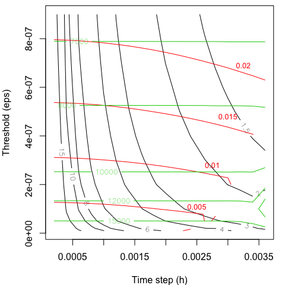

```
##         h   eps   time  nrow     av.nB.err     sum.err      death
## 97 0.0014 3e-07  3.477  9469 -0.0103009794 0.010195353 0.61703418
## 81 0.0018 2e-07  3.065 10579 -0.0097082436 0.007923535 0.48412264
## 65 0.0022 1e-07  3.102 12695 -0.0080154574 0.005331859 0.31720153
## 49 0.0026 5e-08  3.237 15006 -0.0051378488 0.004014944 0.20896084
## 1  0.0002 1e-08 43.621 21233 -0.0006188269 0.000675601 0.06248048
```

=> Lower values of eps can be balanced with higher values of h to improve accuracy without losing speed:

Note: the “death” value is the difference between the inoculum size (10) and the mean number of bacteria at t=6. It varies quite a lot with eps:

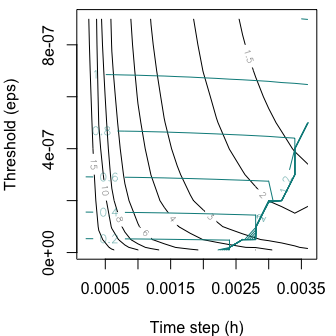

## Further notes

- Version 1c2: create a long matrix from the start instead of using rbind() => no gain of time
- Current tests suggest that the vast majority of variables remain active, so it is unlikely that deleting inactive variables would be efficient.

## What next?

- Use the model to explore sensitivity to parameter values: variance, extinction, correlation between organs.

# Fitting the model to existing data - Inference from complete model solution

See data report

- What the WITS are expected to show is the level of demographic stochasticity within mice, with 8 assumedly independent and identical strains.
- Information on parameter values:
  - e and c govern CFU in blood, but also correlation between liver and spleen following bottleneck;
  - the difference r-k governs the average CFU in each organ
  - the variance in CFU is expected to increase with k => Check with numerical simulations.
- While the model is meant to simulate the numbers of copies of a single WITS, the data provide the total CFU for 8 WITS and their relative proportions. There are two options to fit the model:
  - infer copies of each WITS from the data (CFU x proportion) => **How can error from observation techniques be taken into account?**
  - simulate 8 WITS: pick 8 from the predicted distribution, or perform Gillespie simulations => Sounds complicated.

## Likelihood function

Given parameter values $\Theta$ and initial conditions $\hat{P}_0$, the model gives the probability distribution of system state $N_t=(n_B, n_L, n_S)$ of the system. The set of observations at time *t* in mouse *m* is:

$\begin{aligned} \Omega_{t,m} & = \left(x^B, x^L, x^S, p^B_{1},..., p^B_{7}, p^L_{1},..., p^L_{7}, p^S_{1},..., p^S_{7}; \varphi^B, \varphi^L, \varphi^S\right) \\ & = \left(\omega^B_{1},..., \omega^B_{8}, \omega^L_{1},..., \omega^L_{8}, \omega^S_{1},..., \omega^S_{8}; \varphi^B, \varphi^L, \varphi^S\right) \end{aligned}$

where $x$ represents the cfu counted from a fraction $\varphi$ of the organ, $p_k$ is the proportion of WITS $k$ in the whole sample after plate growth and qPCR, and $\omega^i_k \equiv p^i_k x^i$, with $p_8 \equiv 1-\sum_{k=1}^7 p_k$.

The likelihood of $\Theta$ is equal to: $\begin{aligned} L_{t,m}(\Theta) & = f(\Omega_{t,m}|\Theta) \\ & = \prod_{k=1}^8 f(\omega_k^B,\omega_k^L,\omega_k^S|\Theta) \\ & = \prod_{k=1}^8 \left[ \sum_{n_B,n_L,n_S}f(\omega_k^B,\omega_k^L,\omega_k^S|n_B,n_L,n_S) P(n_B,n_L,n_S|\Theta) \right] \\ & = \prod_{k=1}^8 \left[ \sum_{n_B,n_L,n_S} f(\omega_k^B|n_B) f(\omega_k^L|n_L) f(\omega_k^S|n_S) P(n_B,n_L,n_S|\Theta) \right] \end{aligned}$

The last factor inside the sum is given by the dynamic model, while the first factors describe the measurement process and is therefore less well characterised. Potential sources of error include: - some bacteria may be missed or fail to grow, which could be accounted for by reducing $\varphi$; - colonies may grow at different rates on agar plates, which would need to be measured experimentally.

We assume that all WITS in a mouse are identical and independent of each other. In addition, since the observation process is carried out on individual organs separately, we assume that, given $(n_B, n_B, n_S)$, the observations $\omega_b, \omega_L, \omega_S$ are independent of each other.

**Important note**: the likelihood estimate is dependent upon 3 arbitrary parameters: - $\epsilon$, the threshold in the metadynamical model, - $h$, the time step of the Runge-Kutta algorithm, - $\sigma$, the error introduced by the observation process (from sample collection to qPCR).

**Additional caveat**: the value of $\varphi$ for blood samples is only an approximation, assuming a total blood volume of 2ml. In princple, $f(\omega|n)$ should be modified to take that uncertainty into account, provided that a distribution for $p(\varphi)$ can be obtained from empirical data for the blood.

## Observation process

Initial assumption: conditionally on having $n$ copies of WITS $k$ in organ $i$, $\omega_k^i$ follows a normal distribution with mean $\nu \sim Binom(n,\varphi)$ (actual number of copies in the sample) and an arbitrary variance $\sigma^2$. We will make the assumption that if $\nu=0$, $\omega$ must be 0: $f(\omega|0)=\delta_{\omega=0}$. $f(\omega|n) = \sum_{\nu=0}^n f(\omega|\nu,n) f(\nu|n)$

Two approaches can be taken to estimate empirically the distribution of the observation process: - re-construct it from the qPCR standardisation and from measures of the variation in colony sizes, - more simply by plating known numbers of colonies of each WITS and putting them through qPCR.

## Confidence intervals for parameter MLE

There are two main approaches to measure the uncertainty on MLE (Pawitan 2001):

- **Wald confidence interval**: assuming a normal approximation of the likelihood function, the inverse of the Fisher Information $I(\hat{\Theta})$, defined as the Hessian matrix of $-LL$ at the MLE, provides the covariance matrix of $\hat{\Theta}$, from which 95% confidence intervals and multivariate confidence ellipsoids can be estimated. This assumes regularity of $LL$; it may be necessary to transform the parameters. For individual parameters, the 95% WCI is given by $\hat{\theta_{i}} \pm 1.96 \sqrt{H_{i,i}(\hat{\Theta})^{-1}}$.
- **Likelihood interval**:

Also of interest is the notion of *likelihood profile*, which eliminates nuisance parameters. With two parameters $\alpha$ and $\beta$, the *profile likelihood* of $\alpha$ is $L(\alpha) = \max_{\beta}L(\alpha,\beta) = L(\alpha,\hat{\beta}(\alpha))$.

## Gillespie simulations for approximate likelihood

The current approach becomes very slow and very sensitive to numerical approximations after 24h, especially when allowing mixing between organs. An alternative approach would be to approximate the likelihood by Monte Carlo sampling of $P(n_B,n_L,n_S|\Theta)$ using Gillespie simulations.

The likelihood at time t is approximated by running $N_{sim}$ Gillespie simulations which produce a set $G(\Theta)$ of states $(n_B,n_L,n_S)$ at time $t$:

$\begin{aligned} L_{t}(\Theta) & = \prod_{m=1}^{10} \prod_{k=1}^8 f(\omega_{t,m,k}^B,\omega_{t,m,k}^L,\omega_{t,m,k}^S|\Theta) \\ & = \prod_{m=1}^{10} \prod_{k=1}^8 \left[ \sum_{n_B,n_L,n_S} f(\omega_{t,m,k}^B|n_B) f(\omega_{t,m,k}^L|n_L) f(\omega_{t,m,k}^S|n_S) P(n_B,n_L,n_S|\Theta) \right] \\ & \approx \prod_{m=1}^{10} \prod_{k=1}^8 \left[ \sum_{(n_B,n_L,n_S) \in G(\Theta)} \frac{f(\omega_{t,m,k}^B|n_B) f(\omega_{t,m,k}^L|n_L) f(\omega_{t,m,k}^S|n_S)}{N_{sim}} \right] \end{aligned}$

## Inference based on moments

We have a closed set of 9 linear ODE for the expectation, variance and covariance of $N_B, N_L, N_S$, which can be solved numerically very rapidly at any time. This should enable inference on the 8 model parameters.

We can estimate these 9 moments from each dataset $\Omega(t)$. However, there is no obvious way to generate a likelihood.

Instead, we can assume that the random variables follow an empirical trivariate positive discrete distribution $P_{\Theta}(n_B,n_L,n_S)$ which would be entirely described by the knowledge of the 9 moments. Assuming that each data point $(\omega_B,\omega_L,\omega_S)$ is an observation from this distribution, we can calculate a likelihood as we did before.

The choice of empirical distribution could be guided by Gillespie simulations.

There is a limites choice of multivariate discrete distributions and calculating the pmf may be intensive. The first choice would be negative binomial, which can be defined by its pgf: $F(s_1,s_2,s_3) = \left[a_0 + a_1 s_1 + ... + a_{123} s_1 s_2 s_3 \right]^{-k}$ which has 9 parameters. The 9 moments can be obtained but they are non-linear functions of the 9 parameters, which would make it difficult to re-parameterise $F$. In addition, we will then need to derive the pmf from this pgf.

To circumvent this difficulty, an approximation would bew to assue that the observed $\omega$ are themselves drawn from a continuous trivariate distribution with appropriate moments. A multivariate log-normal distribution might be easier to handle?

**Proposed algorithm**

1. Choose a set of parameters values and a probability distribution of initial conditions $(n_B,n_L,n_S)$.
2. Calculate the 9 moments of the initial conditions.
3. Using (2) as initial conditions, calculate the 9 moments at the desired time t. This involves calculating the exponential of a 3x3 and a 6x6 matrix.
4. Calculate the likelihood based on the ad hoc empirical distribution $P(n_B,n_L,n_S)$ calibrated with the 9 moments from the model.